# PSYC 824: Episode 6

2022/02/18

## Today’s Schedule

- Discussion about NHST, Power, and Effect Size!
  - Led by Nhi and Shanna!
  - Cohen!
  - Kelly & Preacher!
  - Wasserstein & Lazar!
  - Green + a whole ton of people!
  - Wasserstein, Schirm, & Lazar!
  - Bakker, Hartgerink, Wicherts, & van der Maas!
- Starting a data analysis project and some `R` conventions!

## The Readings:

- Cohen, J. (1994). The earth is round (\(p\) < .05). *American Psychologist*, *49*(12), 997-1003.
- Kelley, K., & Preacher, K.J. (2012). On effect size. *Psychological Methods*, *17*(2), 137-152.
- Wasserstein, R. L., & Lazar, N. A. (2016). The ASA Statement on \(p\)-Values: Context, process, and purpose. *The American Statistician*, *70*(2), 129-133.
- Green, C.D., et al. (2018). Statcheck in Canada: What proportion of CPA journal articles contain errors in the reporting of \(p\)-values? *Canadian Psychology*, *59*(3), 203–210.
- Wasserstein, R.L., Schirm, A.L., & Lazar, N.A. (2019). Moving to a World Beyond ‘p \(<\) 0.05’. *The American Statistician*, *73*(1), 1-19.
- Cohen, J. (1992). A power primer. *Psychological Bulletin*, *112*(1), 155-159.
- Bakker, M., et al. (2016). Researchers’ intuitions about power in psychological research. *Psychological Science*, *27*(8), 1069-1077.

## `pwr` (Power) Functions

```r
install.packages("pwr")
library(pwr)
```

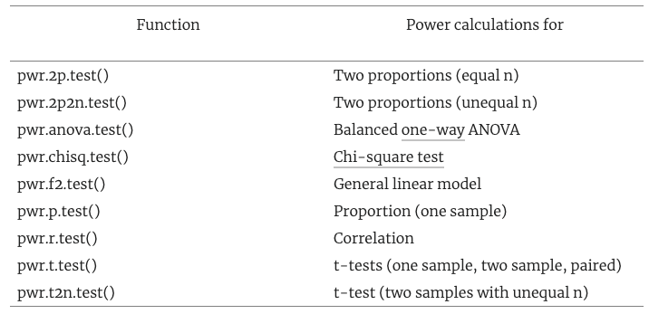

## `pwr` Examples: ANOVA

`pwr.anova.test(k = NULL, n = NULL, f = NULL, sig.level = 0.05, power = NULL)`

- `k`: Number of groups
- `n`: Number of observations (per group)
- `f`: Effect size
- `sig.level`: Significance level (Type I error probability)
- `power`: Power of test (1 minus Type II error probability)

```r
pwr.anova.test(f=0.28,k=4,n=20,sig.level=0.05)
```

```
##
##      Balanced one-way analysis of variance power calculation
##
##               k = 4
##               n = 20
##               f = 0.28
##       sig.level = 0.05
##           power = 0.5149793
##
## NOTE: n is number in each group
```

## `pwr` Examples: Two Proportions

`pwr.2p.test(h = NULL, n = NULL, sig.level = 0.05, power = NULL, alternative = c("two.sided","less","greater"))`

- `h`: Effect size
- `n`: Number of observations (per sample)
- `sig.level`: Significance level (Type I error probability)
- `power`: Power of test (1 minus Type II error probability)
- `alternative`: a character string specifying the alternative hypothesis

```r
pwr.2p.test(h=0.3,n=80,sig.level=0.05,alternative="greater")
```

```
##
##      Difference of proportion power calculation for binomial distribution (arcsine transformation)
##
##               h = 0.3
##               n = 80
##       sig.level = 0.05
##           power = 0.5996777
##     alternative = greater
##
## NOTE: same sample sizes
```

## `pwr` Examples: Chi-Square

`pwr.chisq.test(w = NULL, N = NULL, df = NULL, sig.level = 0.05, power = NULL)`

- `w`: Effect size
- `N`: Total number of observations
- `df`: degree of freedom (depends on the chosen test)
- `sig.level`: Significance level (Type I error probability)
- `power`: Power of test (1 minus Type II error probability)

```r
pwr.chisq.test(w=0.346,df=(2-1)*(3-1),N=140,sig.level=0.01)
```

```
##
##      Chi squared power calculation
##
##               w = 0.346
##               N = 140
##              df = 2
##       sig.level = 0.01
##           power = 0.8854053
##
## NOTE: N is the number of observations
```

## `pwr` Examples: Proportions

`pwr.p.test(h = NULL, n = NULL, sig.level = 0.05, power = NULL, alternative = c("two.sided","less","greater"))`

- `h`: Effect size
- `n`: Number of observations
- `sig.level`: Significance level (Type I error probability)
- `power`: Power of test (1 minus Type II error probability)
- `alternative`: a character string specifying the alternative hypothesis

```r
pwr.p.test(h=0.2,n=60,sig.level=0.05,alternative="two.sided")
```

```
##
##      proportion power calculation for binomial distribution (arcsine transformation)
##
##               h = 0.2
##               n = 60
##       sig.level = 0.05
##           power = 0.3408451
##     alternative = two.sided
```

## Some Additional ResouRces

- Cohen, J. (1992). A power primer. *Psychological Bulletin*, *112*(1), 155-159.
- ‘Understanding Statistical Power and Significance Testing’ (Kristoffer Magnusson):
  - https://rpsychologist.com/d3/nhst/
- Huge collection of `shiny` apps:
  - https://wiki.mgto.org/doku.php/r_shiny_apps#power_and_effect_sizes
  - New link for MOTE: https://doomlab.shinyapps.io/mote/
- A series of blog posts on power analysis via simulation: [Part 1](https://julianquandt.com/post/power-analysis-by-data-simulation-in-r-part-i/); [Part 2](https://julianquandt.com/post/power-analysis-by-data-simulation-in-r-part-ii/); [Part 3](https://julianquandt.com/post/power-analysis-by-data-simulation-in-r-part-iii/);

Other Packages:

- `asypow`: Power calculations via asymptotic likelihood ratio methods
- `PwrGSD`: Power analysis for group sequential designs
- `pamm`: Power analysis for random effects in mixed models
- `powerSurvEpi`: Power and sample size calculations for survival analysis in epidemiological studies
- `gap`: Functions for power and sample size calculations in case-cohort designs
- `ssize.fdr` Sample size calculations for microarray experiments

## Alternatively…

[g*Power](https://www.psychologie.hhu.de/arbeitsgruppen/allgemeine-psychologie-und-arbeitspsychologie/gpower.html)!

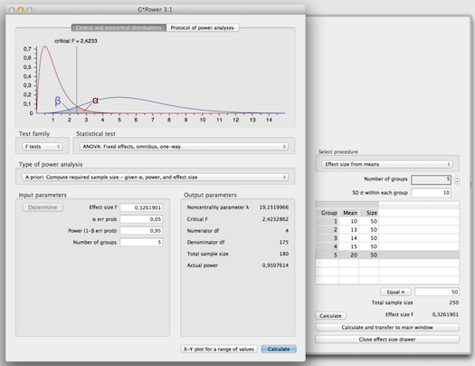

- [UCLA Tutorials on using g*Power](https://stats.idre.ucla.edu/other/gpower/)

## Next Time on…

- Reading Week!
- **March 4th**: Discussion led by Robin!

**Readings on “Measurement”:**

- Calin-Jageman, R.J., & Cumming, G. (2019). The New Statistics for Better Science: Ask How Much, How Uncertain, and What Else Is Known. The American Statistician, 73(1), 271-280.
- Tafreshi, D., Slaney, K. L., & Neufeld, S. D. (2016). Quantification in psychology: Critical analysis of an unreflective practice. Journal of Theoretical and Philosophical Psychology, 36(4), 233–249.
- Baumeister, R.F., Vohs, K.D., & Funder, D.C. (2007). Psychology as the Science of Self-Reports and Finger Movements: Whatever Happened to Actual Behavior? Perspectives on Psychological Science, 2(4), 396–403.
- Schwarz, N. (1999). Self-Reports: How the Questions Shape the Answers. The American Psychologist, 54(2), 93–105.
- Wilson, T.D. (1994). The Proper Protocol: Validity and Completeness of Verbal Reports. Psychological Science, 5(5), 249–252.